# Les médailles olympiques en sport individuel de 1992 à 2024 : exemple du shooting air pistol - 10 meters

Nazma NAZIR HUSSAIN

2024-10-01

# **Présentation du sport**

Le **“shooting air pistol - 10 meters”** signifie en français **“le tir au pistolet à air comprimé - 10 mètres”**. C’est une discipline sportive dans laquelle les compétiteurs utilisent des pistolets pour viser des cibles à des distances prédéfinies. Il s’agit d’un sport de précision, qui exige concentration, stabilité et contrôle.

Le tir, en général, a une longue histoire, notamment liée à l’utilisation des armes à feu pour la chasse et la guerre. L’usage des armes à feu pour le tir sportif est né avec l’invention des premières armes à poudre noire au XIX° siècle. Les premières compétitions formelles de tir ont vu le jour en Europe au XIX° siècle, en particulier dans les pays comme l’Allemagne et la France.

Ce sport a évolué au fil du temps, notamment avec le développement des pistolets modernes à air comprimé et à feu. C’est l’une des disciplines du tir sportif, qui comprend également le tir à la carabine et au fusil.

Le tir au pistolet a fait ses débuts aux premiers Jeux Olympiques modernes en 1896 à Athènes.

Ce document porte sur l’analyse du tir au pistolet à air comprimé de 10 mètres de *1992 à 2024.*

# I- Caractéristiques physiques des vainqueurs

Manu BHAKER est indienne. Elle a obtenu la médaille de Bronze aux Jeux Olympiques de Paris 2024. C’est la première fois qu’une personne originaire de l’Inde qui remporte cette médaille.

[figure not shown]

Manu BHAKER

Tout d’abord, nous allons importer notre base de données qui va nous permettre de réaliser notre analyse.

```r
# Importation des données

don <- read.table(file = "data/mydon_1992_2024.csv",
                  header = TRUE,
                  sep = ";")
```

```r
head(don,3)
```

```
##                                        nom   sex age poids taille pays  ann
## 1 Marina Viktorovna Dobrancheva-Logvinenko Femme  30    63    154  EUN 1992
## 2                  Jasna ekari (Brajkovi-) Femme  26    70    175  IOA 1992
## 3   Mariya Zdravkova Grozdeva (Grigorova-) Femme  20    63    163  BUL 1992
##      titre
## 1     1.Or
## 2 2.Argent
## 3 3.Bronze
```

## Hommes

On va calculé les moyennes et les médianes d’âge, de poids et de taille des médaillés pour cette discipline.

On obtient les résultats suivants :

```r
don_h <-don[don$sex=="Homme",]

# Calculer la moyenne et la médiane en ignorant les NA

moyennestotalesh <- don_h %>% summarize(
    'Âge moyen' = mean(age, na.rm = TRUE),
    'Poids moyen' = mean(poids, na.rm = TRUE),
    'Taille moyenne' = mean(taille, na.rm = TRUE),
    'Âge médian' = median(age, na.rm = TRUE),
    'Poids médian' = median(poids, na.rm = TRUE),
    'Taille médian' = median(taille, na.rm = TRUE)
)

# Afficher le résultat
kable(moyennestotalesh, caption = "Caractéristiques moyenne des hommes sur l'ensemble de la période")
```

Caractéristiques moyenne des hommes sur l’ensemble de la période

| Âge moyen | Poids moyen | Taille moyenne | Âge médian | Poids médian | Taille médian |
| --- | --- | --- | --- | --- | --- |
| 32.25926 | 80.2 | 176.08 | 32 | 78 | 175 |

On va observer plus en détail la répartition au travers des histogrammes pour chacune de ces caractéristiques.

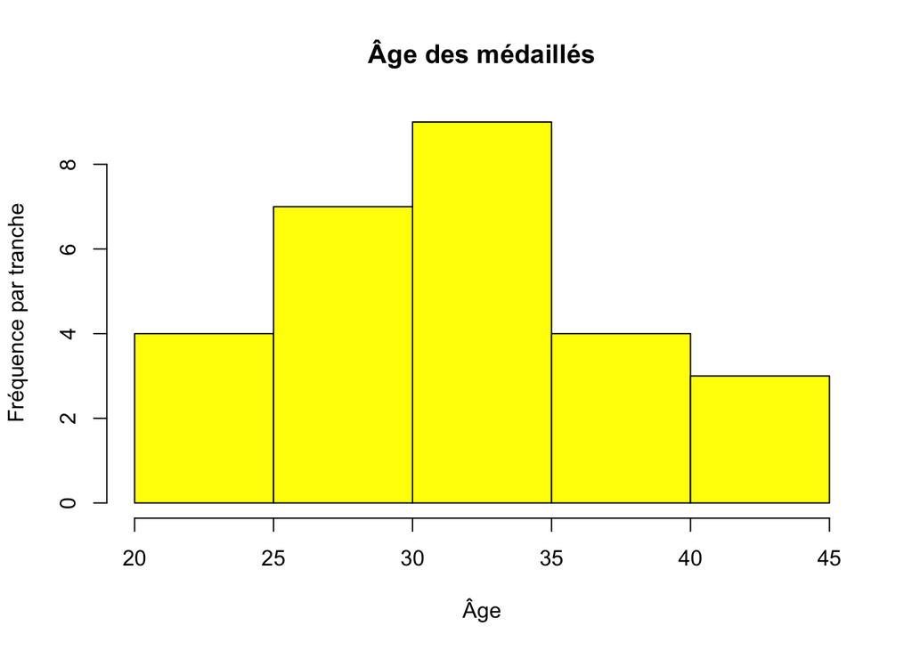

```r
# Puisqu'on a 3 histogrammes on met 33% de out.width pour pouvoir les aligner correctement.

# Histogramme de l'Âge des hommes
hist(don_h$age, breaks=5, probability=FALSE, col="yellow", main = "Âge des médaillés",
        xlab = "Âge", ylab ="Fréquence par tranche")
```

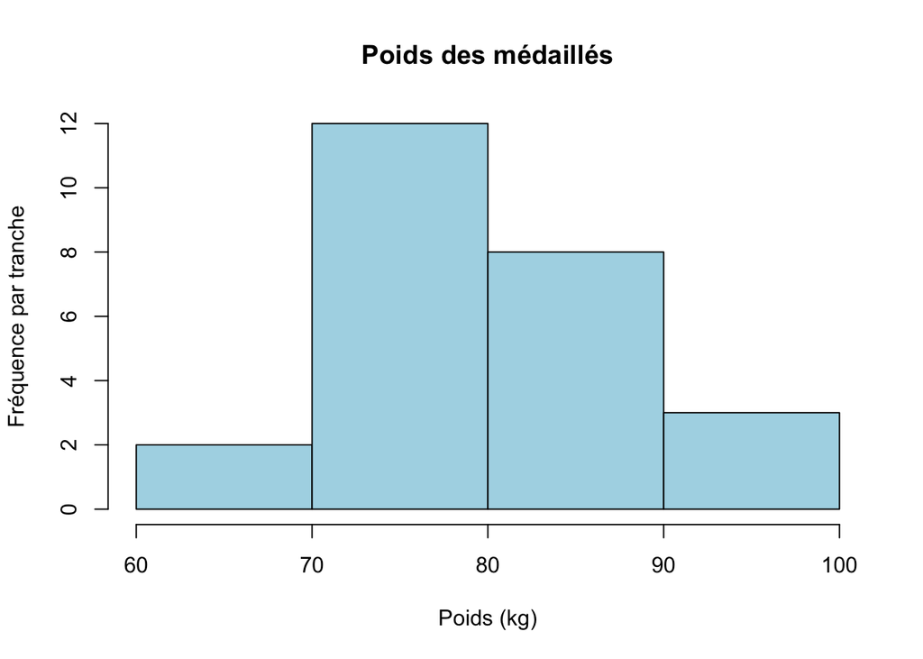

```r
#lines(density(don_h$age,bw=0.3),col="orange",lwd=2) si probability=TRUE pour voir la densité

# Histogramme du poids des hommes
hist(don_h$poids, breaks=5, probability=FALSE, col="lightblue", main = "Poids des médaillés",
        xlab = "Poids (kg)", ylab ="Fréquence par tranche")
```

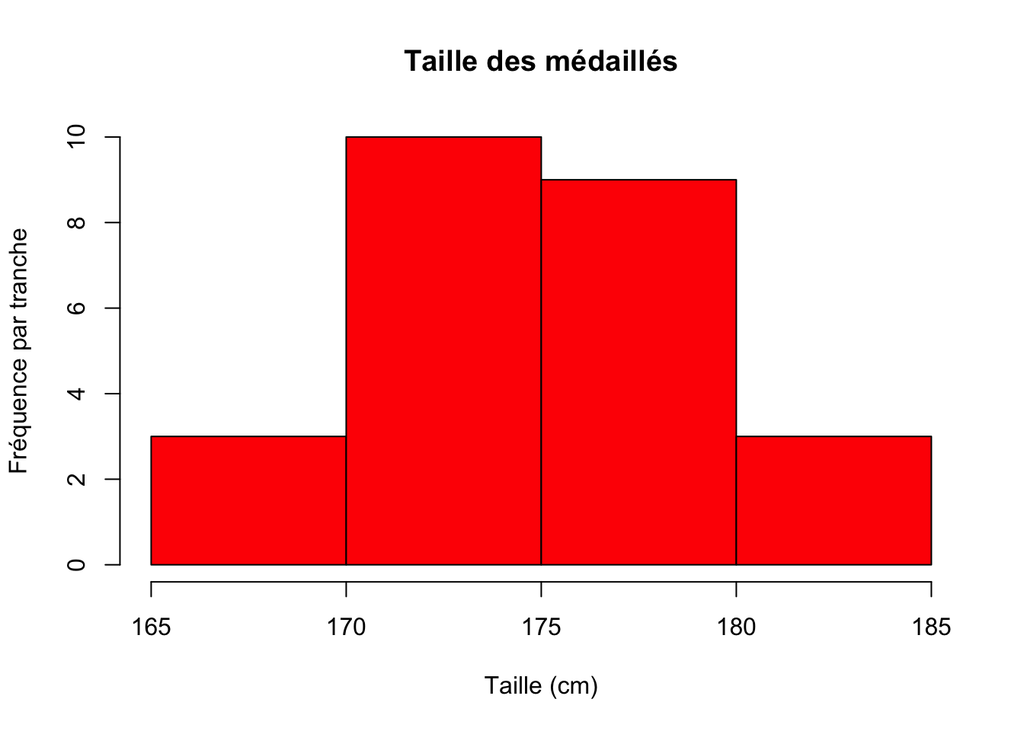

```r
# Histogramme de la taille des hommes
hist(don_h$taille, breaks=5, probability=FALSE, col="red", main = "Taille des médaillés",
        xlab = "Taille (cm)", ylab ="Fréquence par tranche")
```

# Femmes

On va calculer les moyennes et les médianes d’âge, de poids et de taille des médaillés pour cette discipline. On trouve les résultats suivants :

```r
don_f<-don[don$sex=="Femme",]

# Calculer la moyenne totale de l'âge, du poids et de la taille
moyennestotalesf <- don_f %>%
  summarize('Âge moyen' = mean(age, na.rm = TRUE),
    'Poids moyen' = mean(poids, na.rm = TRUE),
    'Taille moyenne' = mean(taille, na.rm = TRUE),
    'Âge médian' = median(age, na.rm = TRUE),
    'Poids médian' = median(poids, na.rm = TRUE),
    'Taille médian' = median(taille, na.rm = TRUE)
)


# On affiche le résultat
kable(moyennestotalesf, caption = "Caractéristiques moyenne des femmes sur l'ensemble de la période")
```

Caractéristiques moyenne des femmes sur l’ensemble de la période

| Âge moyen | Poids moyen | Taille moyenne | Âge médian | Poids médian | Taille médian |
| --- | --- | --- | --- | --- | --- |
| 27.18519 | 62.69231 | 165.2308 | 26 | 63 | 163 |

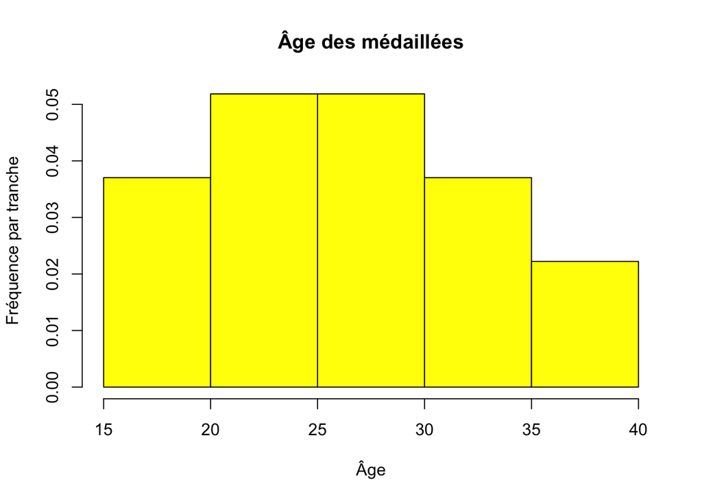

```r
# Histogramme de l'Âge des femmes
hist(don_f$age, breaks=5, probability=TRUE, col="yellow", main = "Âge des médaillées",
        xlab = "Âge", ylab ="Fréquence par tranche")
```

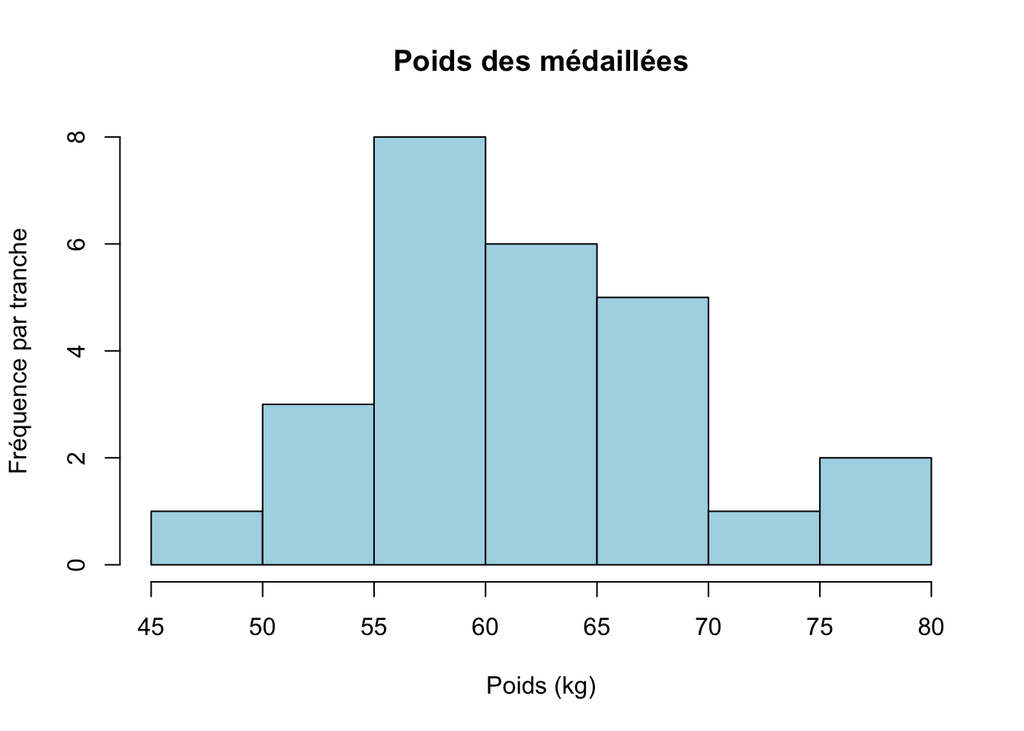

```r
#lines(density(don_f$age,bw=0.3),col="orange",lwd=2) si probability=TRUE pour voir la densité

# Histogramme du poids des femmes
hist(don_f$poids, breaks=5, probability=FALSE, col="lightblue", main = "Poids des médaillées",
        xlab = "Poids (kg)", ylab ="Fréquence par tranche")
```

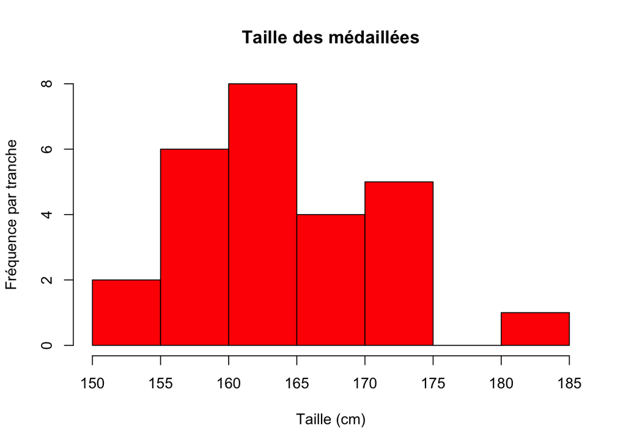

```r
# Histogramme de la taille des femmes
hist(don_f$taille, breaks=5, probability=FALSE, col="red", main = "Taille des médaillées",
        xlab = "Taille (cm)", ylab ="Fréquence par tranche")
```

Les femmes sont globalement plus jeune, avec un âge moyen de 27,19 ans, contre 32,26 ans pour les hommes. La médiane est cohérente avec les moyennes : 50 % des femmes ont 26 ans ou moins, tandis que la moitié des hommes ont 32 ans ou moins. Cela suggère que les femmes sont globalement plus jeune.

Le poids moyen des femmes est de 62,69 kg, significativement inférieur à celui des hommes (80,2 kg). La médiane des poids est proche des moyennes des deux sexes, indiquant une distribution relativement symétrique des poids.

Les femmes sont plus petites, avec une taille moyenne de 165,23 cm, contre 176,08 cm pour les hommes. Cela peut indiquer des différences de constitution physique ou des caractéristiques biologiques. La médiane des tailles est également inférieure pour les femmes (163 cm contre 175 cm pour les hommes), renforçant cette observation.

# Nationalité des vainqueurs

## Résultats globaux

On va tout d’abord regarder les résultats par nation dans cette discipline dans sa globalité. On observe tout d’abord qu’il y 22 pays différents ayant obtenus une ou plusieurs médailles sur la période.

On observe que la Chine a obtenu le plus de médailles dans cette discipline. La Russie obtient la deuxième place.

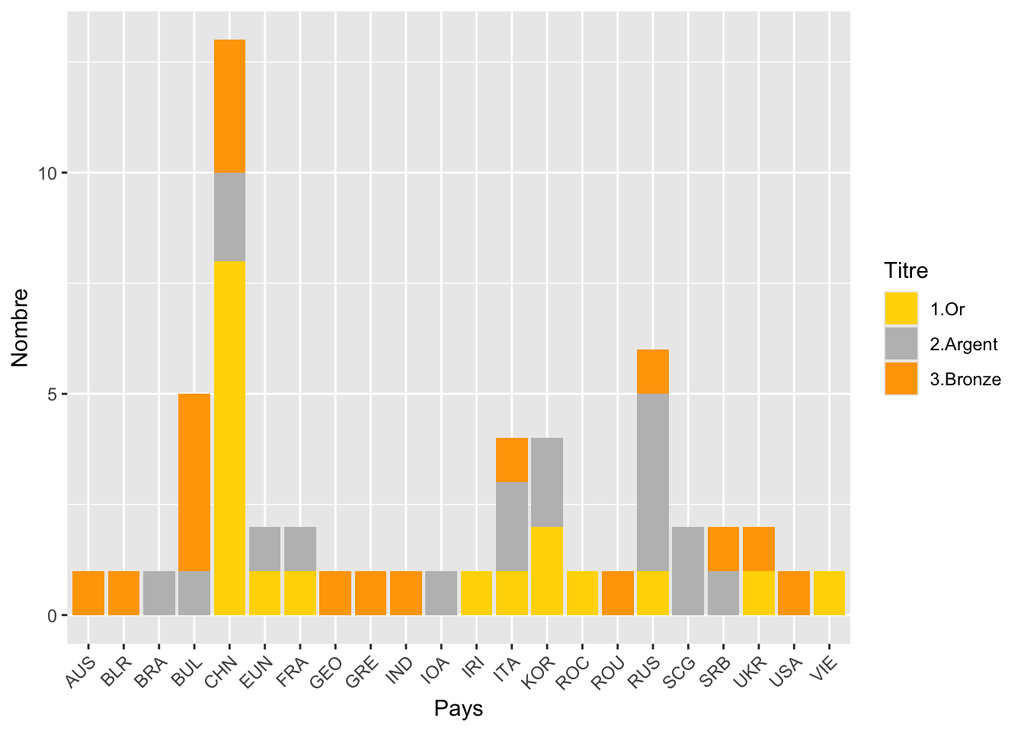

```r
# Compte le nombre de médailles remportées par pays et montre quels sont les médailles en question
nb_med = count(don, pays, titre)

ggplot(nb_med, aes(fill = titre, y = n, x = pays)) +
  scale_fill_manual(values = c("gold", "grey", "orange")) +
  geom_bar(position = position_stack(reverse = TRUE), stat = "identity") +
  labs(x = "Pays", y = "Nombre", fill = "Titre") +
  theme(
    axis.text.x = element_text(angle = 45, hjust = 1)  # Rotation des étiquettes à 45 degrés pour éviter le chevauchement
  )
```

D’autres pays, comme l’Italie (ITA), montrent également une bonne performance, mais nettement inférieure à celle de la Chine (CHN).

## Résultats par sexe

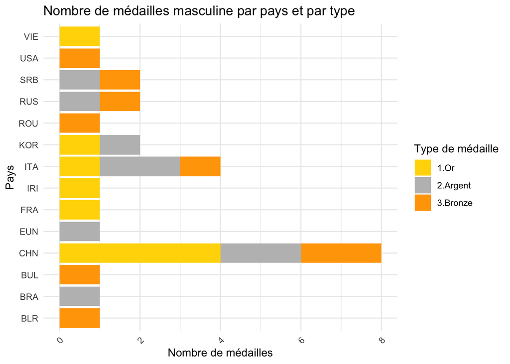

```r
nb_med_h = count(don_h, pays, titre)
#On définie la variable nb_med_h qui compte le nombre de titres différents obtenus par chaques pays

ggplot(nb_med_h, aes(fill=titre, y=pays, x=n)) +
  geom_bar(position = position_stack(reverse = TRUE), stat="identity") +
  scale_fill_manual(values=c("gold", "grey", "orange")) +
  labs(x = "Nombre de médailles", y = "Pays", fill = "Type de médaille", title = "Nombre de médailles masculine par pays et par type") +
  theme_minimal() +
  theme(axis.text.x = element_text(angle = 45, hjust = 1))
```

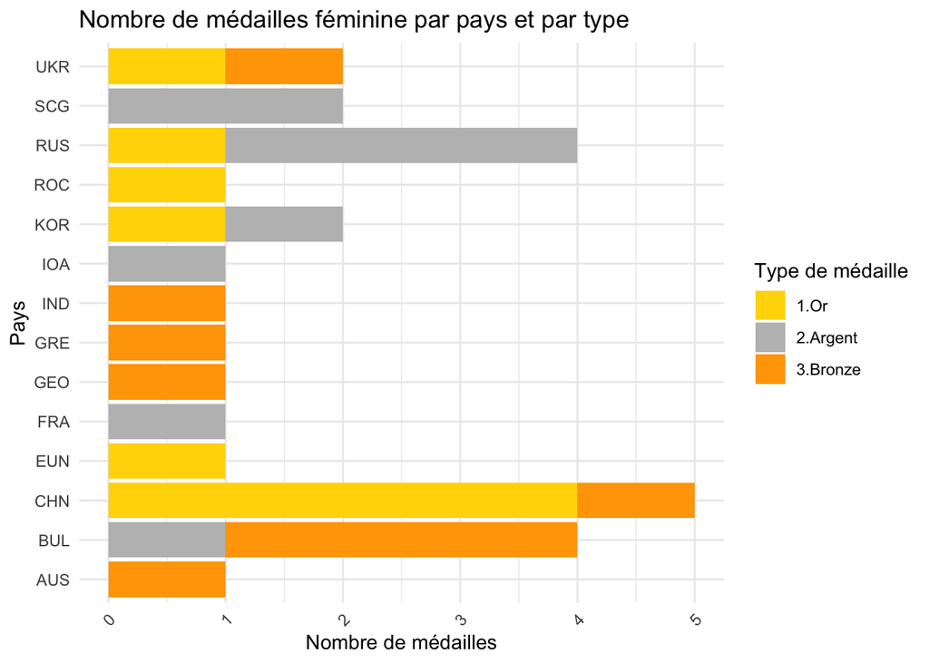

```r
# Pour avoir les médailles correctement ordonnées dans le graphique on utilise dans geom_bar "position = position_stack(reverse = TRUE)"

nb_med_f = count(don_f, pays, titre)
#On définie la variable nb_med_f qui compte le nombre de titres différents obtenus par chaques pays


ggplot(nb_med_f, aes(fill=titre, y=pays, x=n)) +
  geom_bar(position = position_stack(reverse = TRUE), stat="identity") +
  scale_fill_manual(values=c("gold", "grey", "orange")) +
  labs(x = "Nombre de médailles", y = "Pays", fill = "Type de médaille", title = "Nombre de médailles féminine par pays et par type") +
  theme_minimal() +
  theme(axis.text.x = element_text(angle = 45, hjust = 1))
```